# QM640 V1: Data Analytics Capstone

## Address the 2020 Efficiency Anomaly

```python
# Winsorize the 'Miles_per_kWH' data to handle potential outliers, especially the 2020 spike
# Calculate the 1st and 99th percentiles for 'Miles_per_kWH'
lower_bound = merged_df['Miles_per_kWH'].quantile(0.01)
upper_bound = merged_df['Miles_per_kWH'].quantile(0.99)

# Apply Winsorizing by capping values at the calculated bounds
# Values below the lower_bound are replaced with the lower_bound
# Values above the upper_bound are replaced with the upper_bound
merged_df['Miles_per_kWH_winsorized'] = merged_df['Miles_per_kWH'].clip(lower=lower_bound, upper=upper_bound)

print(f"Original Miles_per_kWH min: {merged_df['Miles_per_kWH'].min():.2f}, max: {merged_df['Miles_per_kWH'].max():.2f}")
print(f"Winsorizing bounds: lower={lower_bound:.2f}, upper={upper_bound:.2f}")
print(f"Winsorized Miles_per_kWH min: {merged_df['Miles_per_kWH_winsorized'].min():.2f}, max: {merged_df['Miles_per_kWH_winsorized'].max():.2f}")
```

```
Original Miles_per_kWH min: 1.17, max: 5.60
Winsorizing bounds: lower=1.21, upper=5.60
Winsorized Miles_per_kWH min: 1.21, max: 5.60
```

# **Hypothesis Testing**

## **Research Question H1: Rural-Urban Growth Disparities**

```python
# Calculate the total number of transactions per year for each County_Type
avg_efficiency_by_county_year = merged_df.groupby(['Year', 'County_Type']).size().unstack(fill_value=0)

# Calculate the annual growth rate (percentage change) for each County_Type
growth_rates = avg_efficiency_by_county_year.pct_change() * 100

# Drop the first year (NaN after pct_change)
growth_rates_clean = growth_rates.dropna()

# Separate growth rates for Rural and Urban counties
rural_growth = growth_rates_clean['Rural']
urban_growth = growth_rates_clean['Urban']

# Perform Independent Samples t-test
t_stat, p_value = stats.ttest_ind(rural_growth, urban_growth, equal_var=False) # Welch's t-test, assuming unequal variances

print("\n--- Independent Samples t-test for Annual Growth Rates of Transaction Counts ---")
print(f"Mean Annual Growth Rate of Transactions (Rural): {rural_growth.mean():.2f}%")
print(f"Mean Annual Growth Rate of Transactions (Urban): {urban_growth.mean():.2f}%")
print(f"t-statistic: {t_stat:.3f}")
print(f"p-value: {p_value:.3f}")

if p_value < 0.05:
    print("Conclusion: There is a statistically significant difference in the mean annual growth rates of transaction counts between Rural and Urban counties.")
else:
    print("Conclusion: There is no statistically significant difference in the mean annual growth rates of transaction counts between Rural and Urban counties.")
```

```
--- Independent Samples t-test for Annual Growth Rates of Transaction Counts ---
Mean Annual Growth Rate of Transactions (Rural): 331.25%
Mean Annual Growth Rate of Transactions (Urban): 246.22%
t-statistic: 0.214
p-value: 0.833
Conclusion: There is no statistically significant difference in the mean annual growth rates of transaction counts between Rural and Urban counties.
```

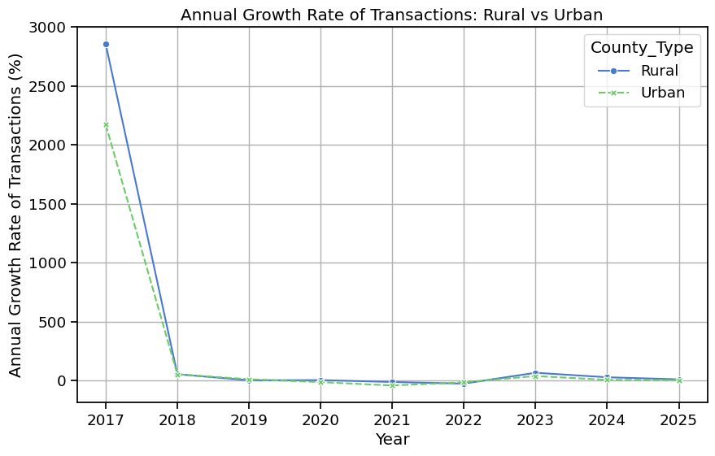

```python
plt.figure(figsize=(10, 6))
sns.lineplot(data=growth_rates_clean, markers=True)
plt.title('Annual Growth Rate of Transactions: Rural vs Urban')
plt.xlabel('Year')
plt.ylabel('Annual Growth Rate of Transactions (%)')
plt.grid(True)
plt.show()
```

```python
# Calculate Cohen's d for the difference in growth rates

def cohen_d(x, y):
    nx = len(x)
    ny = len(y)
    dof = nx + ny - 2
    # Pooled standard deviation
    pooled_std = np.sqrt(((nx - 1) * np.std(x, ddof=1)**2 + (ny - 1) * np.std(y, ddof=1)**2) / dof)
    cohens_d = (np.mean(x) - np.mean(y)) / pooled_std
    return cohens_d

# Calculate Cohen's d using the rural_growth and urban_growth series
d_value = cohen_d(rural_growth, urban_growth)

print(f"\nCohen's d: {d_value:.3f}")

# Interpret Cohen's d
if abs(d_value) < 0.2:
    print("Effect Size: Negligible (less than 0.2)")
elif abs(d_value) < 0.5:
    print("Effect Size: Small (between 0.2 and 0.5)")
elif abs(d_value) < 0.8:
    print("Effect Size: Medium (between 0.5 and 0.8)")
else:
    print("Effect Size: Large (0.8 or greater)")
```

```
Cohen's d: 0.101
Effect Size: Negligible (less than 0.2)
```

The Cohen's d calculation has been successfully executed. The result is Cohen's d: 0.101, which indicates a Negligible Effect Size (less than 0.2). This further supports the conclusion from the t-test that there isn't a significant practical difference in the annual growth rates of transaction counts between Rural and Urban counties. A negligible effect size suggests that even if there were a statistically significant difference (which there wasn't in the t-test), the magnitude of that difference would be very small.

## **Research Question H2: Efficiency Trends**

```python
# Filter data for model years between 2010 and 2025
filtered_df = merged_df[(merged_df['Model Year'] >= 2010) & (merged_df['Model Year'] <= 2025)].copy()

# Drop rows where Miles_per_kWH_winsorized or Model Year might be NaN after filtering (though Model Year should be clean)
filtered_df.dropna(subset=['Miles_per_kWH_winsorized', 'Model Year'], inplace=True)

# Calculate Pearson correlation coefficient and p-value
correlation, p_value = stats.pearsonr(filtered_df['Model Year'], filtered_df['Miles_per_kWH_winsorized'])

print("\n--- Correlation between Model Year and Vehicle Efficiency (Miles/kWh) ---")
print(f"Pearson Correlation Coefficient: {correlation:.3f}")
print(f"P-value: {p_value:.3f}")

if p_value < 0.05:
    print("Conclusion: There is a statistically significant correlation between Model Year and vehicle efficiency (miles/kWh).")
else:
    print("Conclusion: There is no statistically significant correlation between Model Year and vehicle efficiency (miles/kWh).")
```

```
--- Correlation between Model Year and Vehicle Efficiency (Miles/kWh) ---
Pearson Correlation Coefficient: 0.394
P-value: 0.000
Conclusion: There is a statistically significant correlation between Model Year and vehicle efficiency (miles/kWh).
```

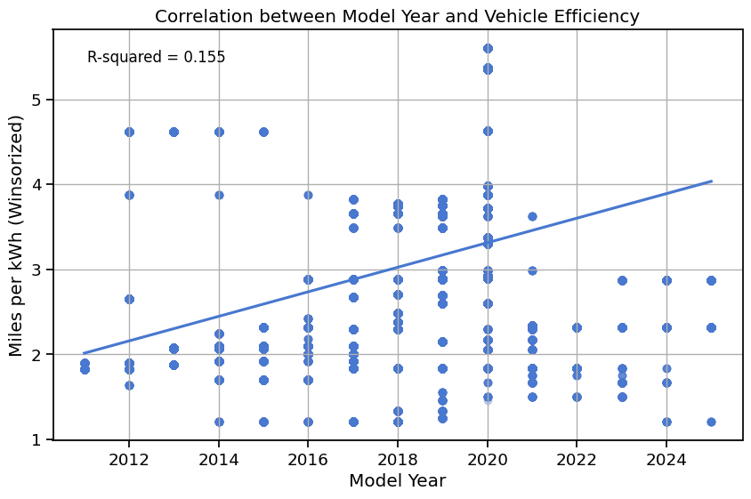

```python
plt.figure(figsize=(10, 6))
sns.regplot(x='Model Year', y='Miles_per_kWH_winsorized', data=filtered_df, scatter_kws={'alpha':0.3})
plt.title('Correlation between Model Year and Vehicle Efficiency')
plt.xlabel('Model Year')
plt.ylabel('Miles per kWh (Winsorized)')
plt.grid(True)

# Add R-squared value to the plot
# For simple linear regression, R-squared is the square of the Pearson correlation coefficient
r_squared_value = correlation**2
plt.text(0.05, 0.95, f'R-squared = {r_squared_value:.3f}', transform=plt.gca().transAxes, fontsize=12, verticalalignment='top')

plt.show()
```

The trend of increasing Miles per kWh as the model year advances, visually confirming the positive correlation we found in the statistical test. The R-squared value of 0.155 is displayed on the plot, indicating that approximately 15.5% of the variance in Miles per kWh can be explained by the Model Year.